11.4 μs

# Naive Bayes: Spam or Ham?

6.5 μs

```
xxxxxxxxxx
```

10

1

```
begin
```

2

```
    using CSV
```

3

```
    using DataFrames
```

4

```
    using Distributions
```

5

```
    using TextAnalysis
```

6

```
    using Languages
```

7

```
    using MLDataUtils
```

8

```
    using Plots
```

9

```
    using Images
```

10

```
end
```

30.5 s

We all hate spam emails. How can Bayes help us with this? What we will be introducing in this chapter is a simple yet effective way of using Bayesian probability to make a spam filter of emails based on their content.

There are many possible origins of the 'Spam' word. Some people suggest Spam is a satirized way to refer to 'fake meat'. Hence, in the context of emails, this would just mean 'fake emails'. It makes sense, but the real story is another one. The origin of this term can be tracked to the 1970s, where the British surreal comedy troupe Monty Python gave life to it in a sketch of their *Monty Python's Flying Circus* series. In the sketch, a customer wants to make an order in a restaurant, but all the restaurant's items have *spam* in them. As the waitress describes the food, she repeats the word spam, and as this happens, a group of Vikings sitting on another table nearby start singing '*Spam, spam, spam, spam, spam, spam, spam, spam, lovely spam! Wonderful spam!* until they are told to shut up.

1.5 ms

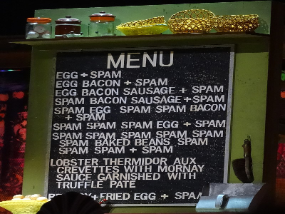

```
xxxxxxxxxx
```

1

1

```
imresize(load("./imgs/spam.jpg"), (300, 400))
```

2.9 s

Although the exact moment where this was first translated to different types of internet messages such as emails or chat messages can't be stated clearly, it is a well known fact that users in each of these messaging instances chose the word 'spam' as a reference to Monty Python's sketch, where spam was itself something unwanted, popping all over the menu and annoyingly trying to drown out the conversation.

6.5 μs

[figure not shown]

431 ms

Now that we have made some historical overview of the topic, we can start designing our spam filter. One of the most important things for the filter to work properly will be to feed it with some good training data. What do we mean by this? In this context, we mean to have a large enough corpus of emails classified as spam or ham (that's the way no-spam emails are called!), that the emails are collected from an heterogeneous group of persons (spam and ham emails will be not be the same from a software developer, a social scientist or a graphics designer), and that the proportion of spam vs. ham in our data is somewhat representative of the real proportion of mails we receive. Fortunately, there are a lot of very good datasets available online. We will be using one from [Kaggle](https://www.kaggle.com/balaka18/email-spam-classification-dataset-csv), a community of data science enthusiasts and practitioners who publish datasets, make competitions and share their knowledge.

This dataset is already a bit pre-processed, as you will probably notice. It consists of 5172 emails, represented by the rows of a matrix or DataFrame. Each column represents a word from the 3000 most frequent words in all mails, and picking a row and a column will tell us how many times a given word appears in a particular email. The last column indicates a 0 for ham emails and 1 for spam. Let's give it a look:

8.3 μsraw_df

Email No.

the

to

ect

and

for

of

a

more

String

Int64

Int64

Int64

Int64

Int64

Int64

Int64

1

```
"Email 1"
```

```
0
```

```
0
```

```
1
```

```
0
```

```
0
```

```
0
```

```
2
```

2

```
"Email 2"
```

```
8
```

```
13
```

```
24
```

```
6
```

```
6
```

```
2
```

```
102
```

3

```
"Email 3"
```

```
0
```

```
0
```

```
1
```

```
0
```

```
0
```

```
0
```

```
8
```

4

```
"Email 4"
```

```
0
```

```
5
```

```
22
```

```
0
```

```
5
```

```
1
```

```
51
```

5

```
"Email 5"
```

```
7
```

```
6
```

```
17
```

```
1
```

```
5
```

```
2
```

```
57
```

6

```
"Email 6"
```

```
4
```

```
5
```

```
1
```

```
4
```

```
2
```

```
3
```

```
45
```

7

```
"Email 7"
```

```
5
```

```
3
```

```
1
```

```
3
```

```
2
```

```
1
```

```
37
```

8

```
"Email 8"
```

```
0
```

```
2
```

```
2
```

```
3
```

```
1
```

```
2
```

```
21
```

9

```
"Email 9"
```

```
2
```

```
2
```

```
3
```

```
0
```

```
0
```

```
1
```

```
18
```

10

```
"Email 10"
```

```
4
```

```
4
```

```
35
```

```
0
```

```
1
```

```
0
```

```
49
```

more

5172

```
"Email 5172"
```

```
22
```

```
24
```

```
5
```

```
1
```

```
6
```

```
5
```

```
148
```

```
xxxxxxxxxx
```

1

1

```
raw_df = CSV.File("./data/emails.csv") |> DataFrame
```

13.4 s

What we are facing here is a **classification** problem, and we will code from scratch and use a **supervised learning** algorithm to find a solution with the help of Bayes' theorem. In particular, we will be using *naive Bayes*. What we are going to do is to treat each email just as a collection of words. The particular relationship between words and the context will not be taken into account here. Our strategy will be to estimate a probability of an incoming email of being ham or spam and making a decision based on that. Our general approach can be summarized as:

email 1: 'are you interested in buying my product?'

email 2: 'congratulations! you've won 1000!'

email 3: 'check out this product!'

new email: 'apply and win all this products!'

As we already said, stands for the plausibility of the new email being generated by the words we encountered in our training spam email set. We can see that words like 'win' –which in our training set appears in the form of 'won', but there is a standard technique in linguistics named **Lemmatization**, which groups together inflected forms of a word, letting us consider 'win' and 'won' as the same word– and 'product' appear rather commonly in our training data. So we will expect to be relatively high in this fake and simple example, as it contains words that are repeated among our spam emails data.

Let's make all this discussion a bit more explicitly mathematical. The simplest way to write this in a mathematical way is to take each word appearing in the email and calculate the probability of it appearing in spam emails and ham emails. Then, we do this for each word in the email and finally multiply them,

The multiplication of each of the word probabilities here stands from the supposition that all the words in the email are statistically independent. We have to stress that this is not necessarily true, and most likely false. Words in a language are never independent from one another, but this simple assumption seems to be enough for the level of complexity our problem requires.

Let's start building a solution for our problem and the details will be discussed later.

17.7 μs

```
x
```

1

```
# preprocessing of the data
```

2

```
begin
```

3

```
    all_words = names(raw_df)[2:end-1];
```

4

```
    all_words_text = StringDocument(join(all_words, " "))
```

5

```
    prepare!(all_words_text, strip_articles)
```

6

```
    prepare!(all_words_text, strip_pronouns)
```

7

```
    vocabulary = filter(x -> x != "", split(TextAnalysis.text(all_words_text)))
```

8

```
    clean_words_df = raw_df[!, vocabulary]
```

9

```
    # the columns of this matrix will be each mail now
```

10

```
    data_matrix = Matrix(clean_words_df)'
```

11

```
end;
```

219 ms

First, we would like to filter some words that are very common in the english language, such as articles and pronouns, and that will most likely add noise rather than information to our classification algorithm. For this we will use two Julia packages that are specially designed for working with texts of any type. These are *Languages.jl* and *TextAnalysis.jl*. A good practice when dealing with models that learn from data like the one we are going to implement, is to divide our data in two: a training set and a testing set. We need to measure how good our model is performing, so we will train it with some data, and test it with some other data the model has never seen. This way we may be sure that the model is not tricking us. In Julia, the package *MLDataUtils* has some nice functionalities for data manipulations like this. We will use the functions *splitobs* to split our dataset in a train set and a test set and *shuffleobs* to randomize the order of our data in the split. It is important also to pass a *labels* array to our split function so that it knows how to properly split our dataset.

13.8 μs

```
xxxxxxxxxx
```

5

1

```
begin
```

2

```
    # splitting of the data in a train and test set
```

3

```
    labels = raw_df.Prediction
```

4

```
    (x_train, y_train), (x_test, y_test) = splitobs(shuffleobs((data_matrix, labels)), at = 0.7)
```

5

```
end;
```

152 μs

Now that we have our data clean and splitted for training and testing, let's return to the details of the calculations. The probability of a particular word, given that we have a spam email, can be calculated like so,

As all this information will be particular for our dataset, so a clever way to aggregate all this is to use a Julia *struct*, and we can define the attributes of the struct that we will be using over and over for the prediction. Below we can see the implementation. The relevant attributes of the struct will be *words*count*ham* and *words*count*spam*, two dictionaries containing the frequency of appearance of each word in the ham and spam datasets, *N_ham* and *N_spam* the total number of words appearing in each category, and finally *vocabulary*, an array with all the unique words in our dataset. The line *BayesSpamFilter() = new()* is just the constructor of this struct. When we instantiate the filter, all the attributes will be undefined and we will have to define some functions to fill these variables with values relevant to our particular problem.

15.2 μs

```
xxxxxxxxxx
```

8

1

```
mutable struct BayesSpamFilter
```

2

```
    words_count_ham::Dict{String, Int64}
```

3

```
    words_count_spam::Dict{String, Int64}
```

4

```
    N_ham::Int64
```

5

```
    N_spam::Int64
```

6

```
    vocabulary::Array{String}
```

7

```
    BayesSpamFilter() = new()
```

8

```
end
```

1.1 ms

6.1 μs

```
words_count (generic function with 2 methods)
```

```
xxxxxxxxxx
```

9

1

```
function words_count(word_data, vocabulary, labels, spam=0)
```

2

```
    # word_data is a matrix where each column is an email and each row is a word
```

3

```
    count_dict = Dict{String, Int64}()
```

4

```
    n_emails = size(word_data)[2]
```

5

```
    for (i, word) in enumerate(vocabulary)
```

6

```
        count_dict[word] = sum([word_data[i,j] for j in 1:n_emails if labels[j]==spam])
```

7

```
    end
```

8

```
    return count_dict
```

9

```
end
```

157 μs

Next, we will define the *fit!* function for our spam filter struct. We are using the *bang*(!) convention for the functions that modify in-place their arguments, in this case, the spam filter struc itself. This will be the function that will fit our model to the data, a typical procedure in Data Science and Machine Learning areas. This fit function will use mainly the *words_count* function defined before to fill all the undefined parameters in the filter's struct.

9.8 μs

```
fit! (generic function with 1 method)
```

```
xxxxxxxxxx
```

8

1

```
function fit!(model::BayesSpamFilter, x_train, y_train, voc)
```

2

```
    model.vocabulary = voc
```

3

```
    model.words_count_ham = words_count(x_train, model.vocabulary, y_train, 0)
```

4

```
    model.words_count_spam = words_count(x_train, model.vocabulary, y_train, 1)
```

5

```
    model.N_ham = sum(values(model.words_count_ham))
```

6

```
    model.N_spam = sum(values(model.words_count_spam))
```

7

```
    return
```

8

```
end
```

31.2 μs

Now it is time to instantiate our spam filter and fit the model to the data. We do this with our training data so then we can measure how well it is working in our test data.

27.5 μs

```
xxxxxxxxxx
```

5

1

```
begin
```

2

```
    # here we instantiate the Bayes filter and then we fit it to our data
```

3

```
    spam_filter = BayesSpamFilter()
```

4

```
    fit!(spam_filter, x_train, y_train, vocabulary)
```

5

```
end
```

392 ms

1.6 ms

```
word_spam_probability (generic function with 1 method)
```

```
xxxxxxxxxx
```

6

1

```
function word_spam_probability(word, words_count_ham, words_count_spam, N_ham,
```

2

```
        N_spam, n_vocabulary, α)
```

3

```
    ham_prob = (words_count_ham[word] + α)/(N_ham + α*(n_vocabulary))
```

4

```
    spam_prob = (words_count_spam[word] + α)/(N_spam + α*(n_vocabulary))
```

5

```
    return ham_prob, spam_prob
```

6

```
end
```

29.2 μs

```
spam_predict (generic function with 2 methods)
```

```
x
```

1

```
function spam_predict(email, model::BayesSpamFilter, α, tol=100)
```

2

```
    ngrams_email = ngrams(StringDocument(email))
```

3

```
    email_words = keys(ngrams_email)
```

4

```
    n_vocabulary = length(model.vocabulary)
```

5

```
    ham_prior = model.N_ham/(model.N_ham + model.N_spam)
```

6

```
    spam_prior = model.N_spam/(model.N_ham + model.N_spam)
```

7

```
    if length(email_words) > tol
```

8

```
        word_freq = values(ngrams_email)
```

9

```
        sort_idx = sortperm(collect(word_freq), rev=true)
```

10

```
        email_words = collect(email_words)[sort_idx][1:tol]
```

11

```
    end
```

12

13

```
    email_ham_probability = BigFloat(1)
```

14

```
    email_spam_probability = BigFloat(1)
```

15

16

17

```
    for word in intersect(email_words, model.vocabulary)
```

18

```
        word_ham_prob, word_spam_prob = word_spam_probability(word, model.words_count_ham, model.words_count_spam, model.N_ham, model.N_spam, n_vocabulary, α)
```

19

```
        email_ham_probability *= word_ham_prob
```

20

```
        email_spam_probability *= word_spam_prob
```

21

```
    end
```

22

```
    return ham_prior*email_ham_probability, spam_prior*email_spam_probability
```

23

```
end
```

61.9 μs

```
0
```

```
xxxxxxxxxx
```

10

1

```
begin
```

2

```
    # this cell is just for testing
```

3

```
    mail_num = 56
```

4

```
    email = string([repeat(string(word, " "), n) for (word, n) in zip(vocabulary, x_test[:,mail_num])]...);
```

5

```
    #nospam_prob, spam_prob = spam_predict(email, train_nospam, train_spam, N_nospam, N_spam, vocabulary, 1)
```

6

```
    ham_prob, spam_prob = spam_predict(email, spam_filter, 1)
```

7

```
    @show ham_prob
```

8

```
    @show spam_prob
```

9

```
    y_test[mail_num]
```

10

```
end
```

47.6 ms

Finally we arrived to the point of actually testing our model. This is what the function below is all about. We feed it with our model fitted with the training data, and the test data we had splitted at the beginning, as well as with the labels of the classification of this data. This function makes a prediction for each email in our test data, using the values of our model and then checks if the prediction was right. We count all the correct predictions and then we divide this number by the total amount of mails, giving us an accuracy measurement.

3.7 μs

```
get_predictions (generic function with 2 methods)
```

```
xxxxxxxxxx
```

12

1

```
#This function classify each mail into Ham(0) or Spam(1)
```

2

```
function get_predictions(x_test, y_test, model::BayesSpamFilter, α, tol=200)
```

3

```
 N = length(y_test)
```

4

```
  predictions = Array{Int64, 1}(undef,N)
```

5

```
  for i in 1:N
```

6

```
    email = string([repeat(string(word, " "),N) for (word,N) in zip(model.vocabulary, x_test[:, i])]...)
```

7

```
    pham, pspam = spam_predict(email, model, α, tol)
```

8

```
    pred = argmax([pham, pspam]) - 1
```

9

```
    predictions[i] = pred
```

10

```
  end
```

11

```
  return predictions
```

12

```
end
```

63.2 μs

Here we can see our model predicts the test mails, 0 for ham and 1 for spam

14.2 μspredictions

Int641

```
1
```

2

```
0
```

3

```
1
```

4

```
0
```

5

```
1
```

6

```
1
```

7

```
0
```

8

```
0
```

9

```
1
```

10

```
0
```

11

```
0
```

12

```
1
```

13

```
0
```

14

```
0
```

15

```
1
```

16

```
0
```

17

```
0
```

18

```
0
```

19

```
1
```

20

```
0
```

more1543

```
1
```

1544

```
1
```

1545

```
0
```

1546

```
0
```

1547

```
0
```

1548

```
0
```

1549

```
0
```

1550

```
0
```

1551

```
0
```

1552

```
0
```

```
xxxxxxxxxx
```

1

1

```
predictions = get_predictions(x_test, y_test, spam_filter, 1)
```

7.1 s

```
spam_filter_accuracy (generic function with 1 method)
```

```
xxxxxxxxxx
```

6

1

```
function spam_filter_accuracy(predictions, actual)
```

2

```
 N = length(predictions)
```

3

```
  correct = sum(predictions .== actual)
```

4

```
  accuracy = correct /N
```

5

```
  return accuracy
```

6

```
end
```

22.3 μs

As you can see below, the model (at least under this simple metric) is performing very well! An accuracy of about 0.95 is quite astonishing for a model so *naive* and simple, but it works!

4.8 μs

```
0.9574742268041238
```

```
xxxxxxxxxx
```

1

1

```
spam_filter_accuracy(predictions, y_test)
```

12.3 μs

But we have to take into account one more thing. Our model classifies mails into spam or ham and the amount of ham mails is considerably higher than the spam ones. Let's see the percentages

8.1 μs

```
0.367012117554204
```

```
x
```

1

```
sum(x_train)/length(x_train)
```

176 ms

194 ms

This classification problemas where there is an unequal distribution of classes in the dataset are called Imbalanced classification problems.

So a good way to see how our model is performing is to construct a confusion matrix. A Confusion matrix is an N x N matrix, where N is the number of target classes. The matrix compares the actual target values with those predicted by the our model. Lets construct one for our model:

3.4 μs

```
splam_filter_confusion_matrix (generic function with 1 method)
```

```
xxxxxxxxxx
```

25

1

```
function splam_filter_confusion_matrix(y_test,predictions)
```

2

3

```
    #We create the matrix and calculated their values
```

4

```
    confusion_matrix= [0 0 ; 0 0]
```

5

6

```
    confusion_matrix[1,1] = sum(isequal(y_test[i],0) & isequal(predictions[i],0) for i in 1:length(y_test))
```

7

```
    confusion_matrix[1,2] = sum(isequal(y_test[i],1) & isequal(predictions[i],0) for i in 1:length(y_test))
```

8

```
    confusion_matrix[2,1] = sum(isequal(y_test[i],0) & isequal(predictions[i],1) for i in 1:length(y_test))
```

9

```
    confusion_matrix[2,2] = sum(isequal(y_test[i],1) & isequal(predictions[i],1) for i in 1:length(y_test))
```

10

11

```
    #Now we convert the confusion matrix into a DataFrame
```

12

```
    confusion_df = DataFrame(Prediction = String[],
```

13

14

```
                Ham_mail = Int64[],
```

15

16

```
                Spam_mail = Int64[])
```

17

18

```
    confusion_df = vcat(confusion_df,DataFrame(Prediction = "Model predicted Ham", Ham_mail = confusion_matrix[1,1] , Spam_mail = confusion_matrix[1,2]))
```

19

20

```
    confusion_df = vcat(confusion_df ,DataFrame(Prediction = "Model predicted Spam", Ham_mail = confusion_matrix[2,1] , Spam_mail = confusion_matrix[2,2]))
```

21

22

```
    return confusion_df
```

23

24

25

```
end
```

95.9 μsconfusion_matrix

Prediction

Ham_mail

Spam_mail

String

Int64

Int64

1

```
"Model predicted Ham"
```

```
1079
```

```
36
```

2

```
"Model predicted Spam"
```

```
30
```

```
407
```

```
xxxxxxxxxx
```

1

1

```
confusion_matrix = splam_filter_confusion_matrix(y_test[:],predictions)
```

183 μs

So now we can calculate the accuracy of the model segmented by category.

2.5 μsham_accuracy

```
0.9729486023444545
```

```
xxxxxxxxxx
```

1

1

```
ham_accuracy = confusion_matrix[1,"Ham_mail"]/(confusion_matrix[1,"Ham_mail"] + confusion_matrix[2,"Ham_mail"])
```

5.1 μsspam_accuracy

```
0.9187358916478555
```

```
xxxxxxxxxx
```

1

1

```
spam_accuracy = confusion_matrix[2,"Spam_mail"]/(confusion_matrix[1,"Spam_mail"] + confusion_matrix[2,"Spam_mail"])
```

5.3 μs

### Summary

In this chapter, we have used a naive-bayes approach to build a simple email spam filter. First, the dataset and the theoretical framework were introduced. Using Bayes' theorem and the data available, we assigned probability of belonging to a spam or ham email to each word of the email dataset. The probability of a new email being classified as spam is therefore the product of the probabilities of each of its constituent words. Later, the data was pre-processed and a struct was defined for the spam filter object. Functions were then implemented to fit the spam filter object to the data. Finally, we evaluated our model performance calculating the accuracy and making a confusion matrix.

5.9 μs

### References

- [What is Spam Filtering?](https://www.mailchannels.com/what-is-spam-filtering/)
- [Artificial Intelligence in Python: A Comprehensive Guide to Building Intelligent Apps for Python Beginners and Developers](https://www.amazon.com/Artificial-Intelligence-Python-Comprehensive-Intelligent-ebook/dp/B01IRD0LBY)
- [Data Algorithms: Recipes for scaling up with Hadoop and Spark](https://www.amazon.com/Data-Algorithms-Recipes-Scaling-Hadoop/dp/1491906189)
- [Doing Data Science: Straight talk from the frontline](https://www.oreilly.com/library/view/doing-data-science/9781449363871/)
- [How the word 'Spam' came to mean 'Junk Message'](http://www.todayifoundout.com/index.php/2010/09/how-the-word-spam-came-to-mean-junk-message/)
- [Monty Python Sketch - YouTube](https://www.youtube.com/watch?v=zLih-WQwBSc)

3.1 ms

### Give us feedback

This book is currently in a beta version. We are looking forward to getting feedback and criticism:

- Submit a GitHub issue **[here](https://github.com/unbalancedparentheses/data_science_in_julia_for_hackers/issues)**.
- Mail us to **martina.cantaro@lambdaclass.com**

Thank you!

13.9 μs

[Next chapter](https://datasciencejuliahackers.com/05_prob_prog_intro.jl.html)

4.3 μs